# MUM 2024-25 model Transformera

```python
import math
import torch
from torch import nn
# from d2l import torch as d2l
import matplotlib
import numpy as np
import matplotlib.pyplot as plt
%matplotlib inline
```

## Transformer jako model predykcyjny (rysunki inspirowane A. Canzoni))

- problemem modelu rekurencyjnego jest próba przetwarzania sekwencji o dowolnej długości co zwykle powoduje zapominanie odległych zależności
  - enkoder przetwarza całe wejście i zapamiętuje je w reprezentacji latent
  - dekoder jest inicjalizowany tym wektorem kontekstu

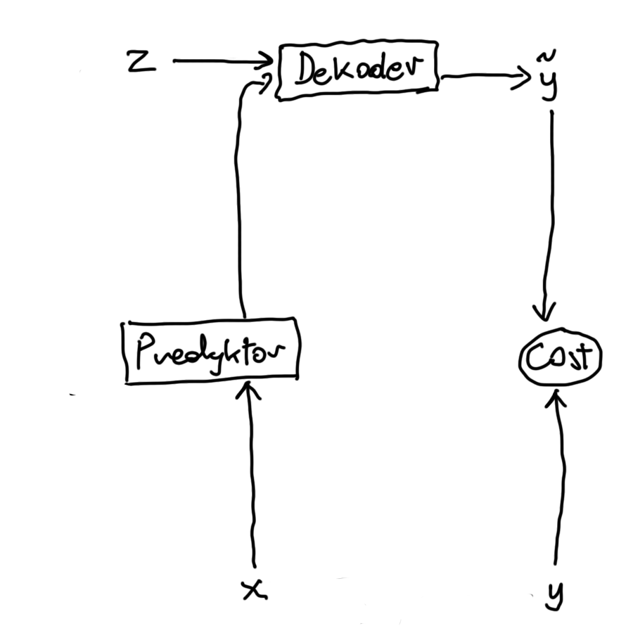

- mamy zmienną celu $y$, zmienną wejściową (warunkową, obserwacją), na tej podstawie model przewiduje $\tilde{y}$
  - do tego zmienna $z$, która określa pewne warunki, np. ograniczające przedział gdzie jest generowane $\tilde{y}$
  - to jest model typu **EBM** — Energy Based Model
    - ciągła minimalizacja dynamicznie optymalizuje jest koszt
  - ten model jest rozszerzeniem autoenkodera, który nie ma zmiennej warunkowej $z$, a jedynie odtwarza wartość $y$ także przechodząc przez przestrzeń latent $h$
  - model uczy się przez minimalizację kosztu (energii) $C$

## Transformer jako model predykcyjny (rysunki inspirowane A. Canzoni))

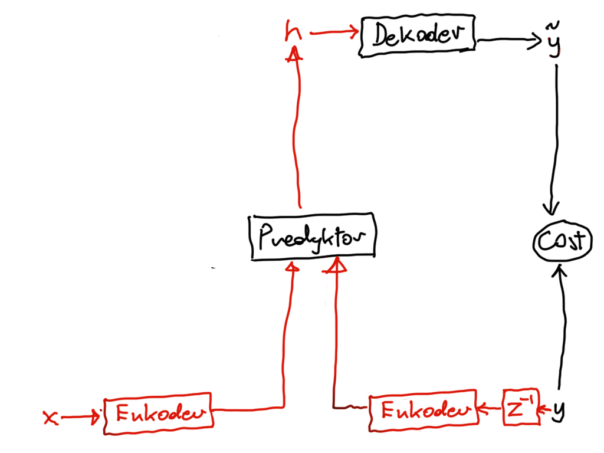

- model transformera jest rozszerzeniem tego modelu o predykcję oraz dekoder
  - jak wcześniej ze zmiennej $y$ odtwarzana jest wartość $\tilde{y}$, z wykorzystaniem dekodera
  - jednak $\tilde{y}$ jest **przewidywaniem** z wartości **poprzedzającej** $z^{-1}(y)$
    - to jest model enkodowania — predykcji — dekodowania,
    - nie enkodowania — dekodowania, jak w autoenkoderze
    - w modelu tłumaczenia będzie to poprzednie wygenerowane słowo (token)
  - przestrzeń ukryta jest predykcją wartości ukrytej $h$
    - $h$ jest wartością ukrytą, z której dekoder odtwarza $\tilde{y}$
    - $h$ jest przewidywany przez Predyktor z pary złożonej
      - zmienna obserwowana $x$, zakodowana przez enkoder
      - wartość $z^{-1}(y)$ (poprzedzająca $y$), też zakodowana przez enkoder
        - to różnicuje ten fragment od autoenkodera
        - także bardzo podobne do *denoising autoenkoder*, dzie zamiast $z^{-1}$ mamy dodany szum
    - obecność zmiennej $x$ stanowi, że jest to model *warunkowy*
- w *Attention is all you need* (Vaswani et al.) cała prawa strona jest nazywana dekoderem, co nie dokładnie jest prawdą (na co zwraca uwagę właśnie Canzoni, NYU, u prof. Y. LeCun-a)
  - w rzeczywistości model przewiduje wykorzystując $z^{-1}(y)$, *poprzedniego* stanu $y$
  - wykorzystuje także predyktor
  - cały ten moduł jest złożeniem predyktor-dekoder

### enkoder

- bardzo istotne: wejściem i wyjściem są zbiory tokenów, tokenów zakodowanych, rozkładów wyjścia

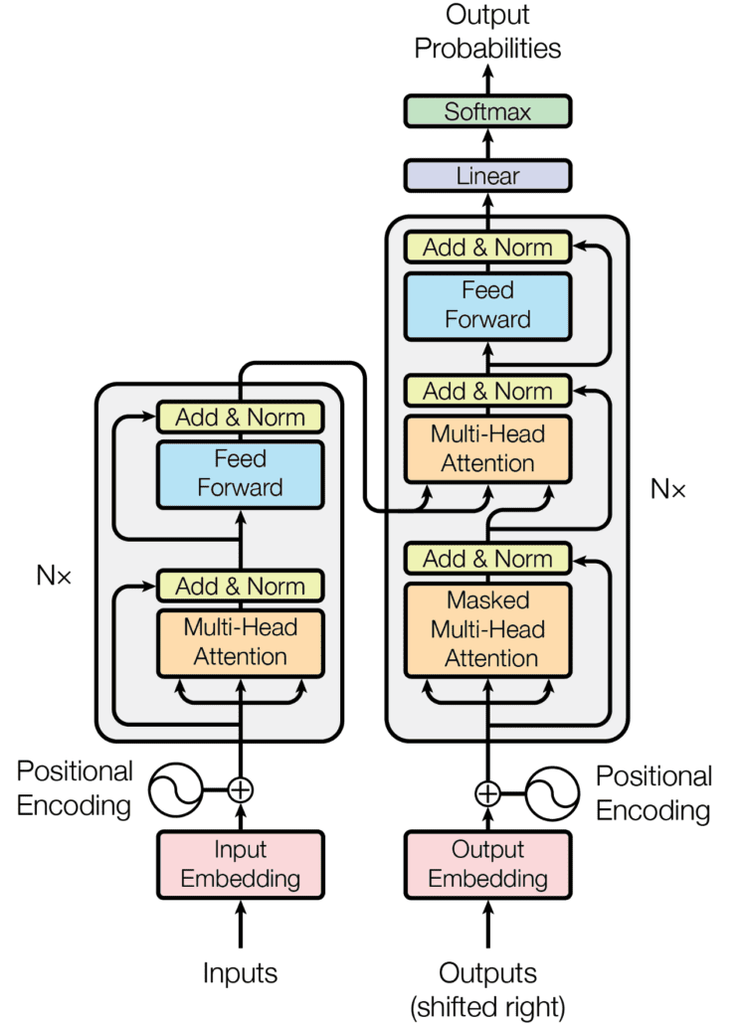

- na wejściu z sygnału obserwowanego obliczana jest self-attention, wielogłowicowe i przetwarzana przez
  - warstwę `Add` $f(x)=ReLU(W_ax+b_a)W_l+b_l$
  - normalizację `Norm` $Norm(Add(x)+x)$
    - $x\equiv{}(x,x,x)\equiv{}(Q,K,V)$
    - często jako warstwa konwolucji o szerokości 1
  - wyjściem jest warstwa ukryta dla całego zbioru tokenów
  - warstwy rezydualne są konieczne na zwykle bardzo głęboką architekturę
    - bez struktury rezydualnej, model traci informację o oryginalnej sekwencji
      - atencja wielogłowicowa ignoruje pozycję
      - informacja o kolejności byłaby zgubiona już po pierwszej inicjalizacji
      - przy losowej inicjalizacja query i kluczy wyjście **nie ma już żadnego** związku z oryginalnym wejściem
      - alternatywą może być ustalenie jednej głowy związanej z oryginalnym wejściem
        - nieefektywne
  - istotna jest też normalizacja, a dokładnie [`LayerNormalization`](https://pytorch.org/docs/stable/generated/torch.nn.LayerNorm.html)
    - pozwala na szybsze uczenie i niedużą regularyzację
    - LayerNormalization aplikuje normalizację per-przykład co oszczędza pamięć
  - mała sieć feed-forward o architekturze Linear -> ReLU -> Linear $$\begin{align} MLP(x)&=max(0, xW_1+b_1)W_2+b_2\\ x&=LayerNorm(x+MLP(x)) \end{align}$$

### predyktor - dekoder

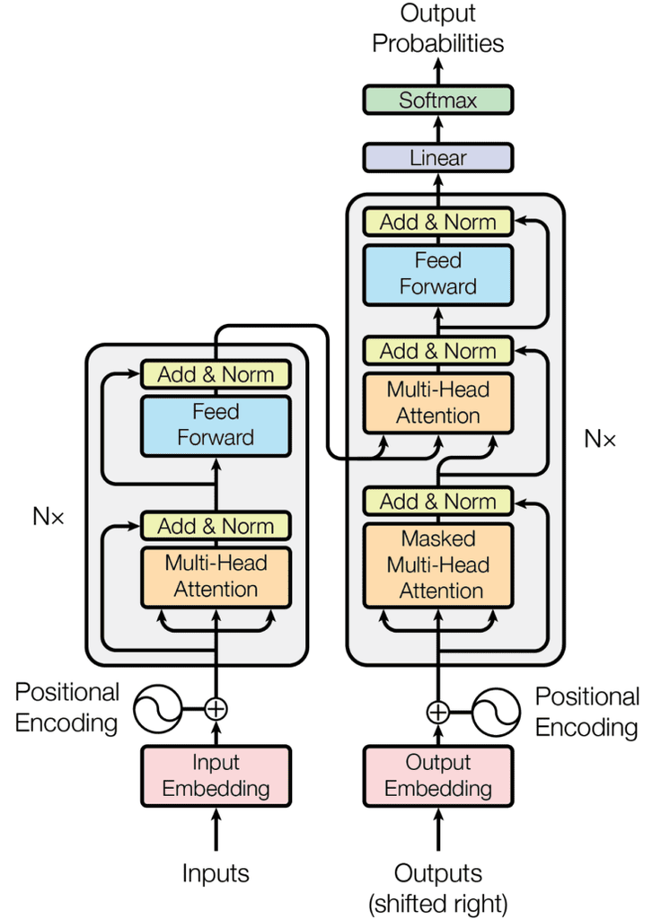

- na wejściu tokeny sygnały wyjściowego, **przesunięte wstecz o jeden** wraz z wielogłowicową self-atencją
  - patrz $z^{-1}y$ w modelu enkoder-predyktor-dekoder transformera
  - wtedy warstwa `Add-Norm` (rezydualna)
  - znowu rezydualna self attention **rozszerzona** o ukrytą reprezentację z enkodera
  - warstwa rezydualna feed-forward służy do predykcji kolejnej reprezentacji ukrytej z przetworzonych atencji sygnału wyjściowego oraz wyjściowego
    - FF przetwarza wszystkie wejścia niezależnie od ich pozycji - stąd często FF zwana *position-wise*
  - zwraca, przez końcowe `softmax`, prawdopodobieństwa
- w implementacjach moduły enkodera i dekodera powtarzają się N krotnie, zwykle $N\in[6,60]$
- w opisie, względem rysunku, brakuje na razie
  - maskowania wejść
  - kodowania pozycyjnego
- enkoder bada atencje **wszystkich** par elementów w sekwencjach
- dekoder szuka atencji **tylko** wstecz -- prawa górna część macierzy jest wypełniona $-\infty$

### Atencja

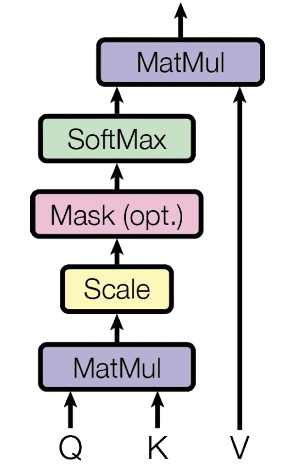

- obliczanie atencji jest oczywiste
  - wymnożenie macierzy queries i kluczy
  - skalowanie
  - ewentualne maskowanie nieporzebnych, czy niepoprawnych, relacji
  - softmax
  - wymnożenie z macierzą wartości

### kroki obliczeń

[wizualizacja działania transformera](https://poloclub.github.io/transformer-explainer)

1. inicjalizacja wektorów query, keys, values
- odpowiada przemnożeniu embeddingu tokena przez odpowiednią macierz $W^Q$, $W^K$, $W^V$ nauczone w procesie
2. obliczenie score
- to odpowiada policzeniu iloczynu skalarnego dla wektora q przez wektor k, a więc na ile key pasuje do query
- obliczenia dla wszystkich par query i key
4. podzielenie każdej z tych wartości przez pierwiastek z długości reprezentacji (embeddingu)
- to daje lepszą stabilność obliczeń dzięki stałej wariancji
6. policzeniu softmax dla każdej z wartości
- wartości dla wszystkich tokenów sumują się do jedności
8. przemnożenie każdej wartości value przez obliczony softmax
- to wzmacnia tokeny istotne i osłabia te nieistotne
10. sumowanie ważonych wartości
- to daje wyjście warstwy atencji na tej pozycji
- oczywiście wszystkie te obliczenia są dla całych sekwencji, a wobec tego są na macierzach
  - patrz skrypt o Atencji

### Maskowanie

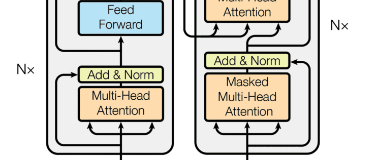

- przy przetwarzaniu sekwencji, np. NLP, trzeba zadbać o możliwe niepoprawne atencje
  - maskowanie polega na usunięciu wartości w $QK^T$, które odpowiadają atencjom między danym tokenem, a tokenami następującymi po nich
  - predyktor — dekoder staje się jednokierunkowy

### kodowanie pozycyjne

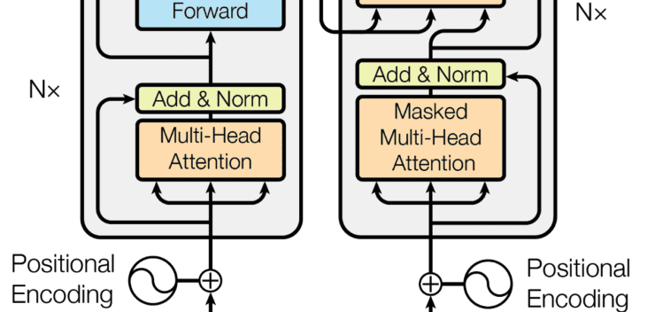

- taka architektura przetwarza *zbiory* tokenów
  - RNN przetwarza sekwencyjnie
  - Transformer nie może dodać "indeksu cechy" bo po normalizacji będzie to *nic nie znacząca* wartość z [0, 1]
  - tłumaczenie gdzie transformer zapamiętuje wszystkie zależności z wszystkimi innymi tokenami bez konieczności budowy specjalnej architektury i specjalnego trybu przetwarzania
  - przetwarzanie obrazów gdzie można obrabiać fragmenty obrazów, także wyszukując zależności między nimi bez wpisywania *explicite*, które nas interesują ani jak to trzeba robić
  - kodowanie potrzebne dla **odtworzenia** postaci wyjściowej z wynikowego zbioru
- kodowanie pozycyjne przez dodatkową informację związaną z tokenem
- embedding jest także parametrem modelu
  - macierz kodowania jest także uczona
  - kodowanie w postaci $X'=X+P$, gdzie $P$ pozwala na odtworzenie kolejności po przetworzeniu sekwencji $X$ [Vawani,Shazeer,Parmar,Uszkoreit,Jones,Gomez,Kaiser,Polosukhin, "Attention is all you need", 2017](https://arxiv.org/pdf/1706.03762.pdf)
  - każda pozycja $i$ w sekwencji $0\leq{}i\lt{}L/2$, o wymiarze kodowania $d$ ma przypisany wektor dla stałej $n$ (równej 10,000 u Vaswani et al.) $$ \begin{align} p_{i, 2j}&=\sin\left(\dfrac{i}{n^{2j/d}}\right)\\ p_{i, 2j+1}&=\cos\left(\frac{i}{n^{2j/d}}\right)\\ \end{align} $$

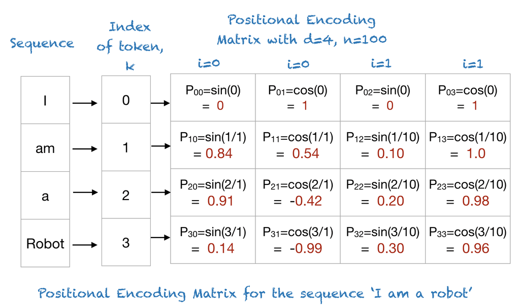

    [Saeed]
  - taka reprezentacja odpowiada coraz niższej częstotliwości sygnału w kolejnych (o wyższym indeksie) kolumnach
    - odpowiada to reprezentacji binarnej - im wyższy w niej bit, tym ma mniejszą częstotliwość (rzadziej się zmienia)
    - sinusoida dla każdej pozycji jest inna, stąd jednoznaczne kodowanie
  - prezentacja na podstawie pakietu `d2l`

```python
class PositionalEncoding(nn.Module):  #@save
    """Positional encoding."""
    def __init__(self, num_hiddens, dropout, max_len=1000):
        super().__init__()
        self.dropout = nn.Dropout(dropout)
        # Create a long enough P
        self.P = torch.zeros((1, max_len, num_hiddens))
        X = torch.arange(max_len, dtype=torch.float32).reshape(
            -1, 1) / torch.pow(10000, torch.arange(
            0, num_hiddens, 2, dtype=torch.float32) / num_hiddens)
        self.P[:, :, 0::2] = torch.sin(X)
        self.P[:, :, 1::2] = torch.cos(X)

    def forward(self, X):
        X = X + self.P[:, :X.shape[1], :].to(X.device)
        return self.dropout(X)
```

```python
# im wcześniejsza kolumna, tym wyższa częstotliwość
encoding_dim, num_steps = 64, 64
pos_encoding = PositionalEncoding(encoding_dim, 0)
X = pos_encoding(torch.zeros((1, num_steps, encoding_dim)))
P = pos_encoding.P[:, :X.shape[1], :]
left, right = 7, 11
d2l.plot(torch.arange(num_steps), P[0, :, left:right].T,
         xlabel='Row (position)', figsize=(7.5, 3.5),
         legend=["Col %d" % d for d in torch.arange(left, right)])
```

[figure not shown]

```python
up = P[0, :, :].unsqueeze(0).unsqueeze(0)
d2l.show_heatmaps(up, xlabel='Column (encoding dimension)',
                  ylabel='Row (position)', figsize=(7.0, 4.5), cmap='Blues')
```

[figure not shown]

## Użycie do przetwarzania obrazów

- Transformer oryginalnie do zadań typu NLP, a rozpoznawanie obrazów pozostawało domeną CNN
- Transformer może pobierać fragmenty (ang. patches) obrazów jako tokeny [[Dosovitskiy,Beyer,Kolesnikov,Weissenborn,Zhai,Unterthiner,Dehghani,Minderer,Heigold,Gelly,Uszkoreit,Houlsby, "An Image is Worth 16x16 Words: Transformers for Image Recognition at Scale", 2020]](https://arxiv.org/pdf/2010.11929.pdf)

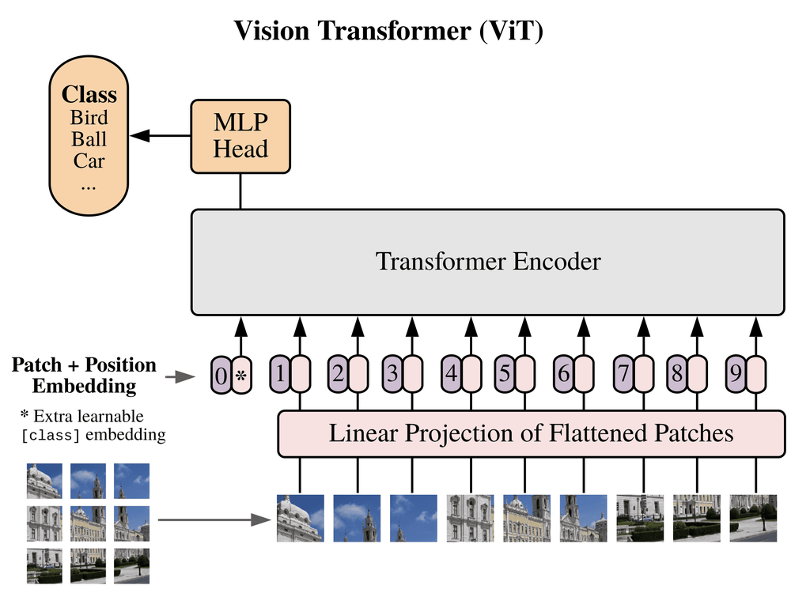

- Vision Transformer jest modelem dzielącym słowa na **sekwencję patchy** z odpowiednim pozycjonowaniem
- niech obraz ma wymiary $x\times w$, i $c$ kanałów
  - podzielone na patche $p\times p$ dając $m=h * w / p^2$ patchy
  - każdy patch jako wektor $c * p^2$ dając token
  - $m$ patchy oraz specjalny znacznik jest *liniowo* rzutowane dając embeddingi
    - podział na patche i rzutowanie można wykonać używając pojedynczej konwolucji
    - znacznik **bierze udział we wszystkich operacjach self-attention**
      - reprezentacja znacznika jest zależna od obrazów
      - na wyjściu pobierana jest utworzona reprezentacja znacznika i po normalizacji plus MLP generuje **reprezentację wyjściowej klasy**

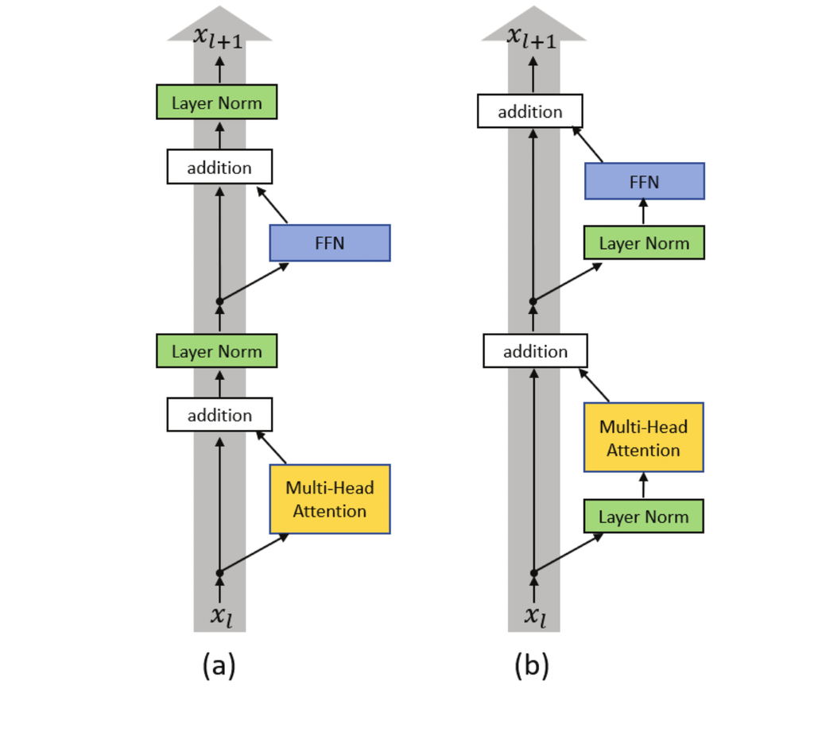

        [(a) post-layernorm, (b) pre-layernorm]
- obrazy są podzielone na często bardzo małe patche
  - rozpoznanie z małych patchy jest trudne, jednak z sekwencji możliwe
  - warstwa normalizacji **przed** atencją prowadzi do efektywniejszego uczenia (tryb **pre-layernorm**, na rysunku po **prawej**)
- enkoder wykorzystuje funkcję aktywacji [`GELU`](https://pytorch.org/docs/stable/generated/torch.nn.GELU.html#torch.nn.GELU) $$\dfrac{1}{2}*x*[1+erf(x/\sqrt(x))]$$ którą można potraktować jako gładką ReLU z minimum blisko poniżej zera
  - dodatkowe warstwy dropout
- dla prostych / nie za dużych zbiorów danych Transformer nie jest lepszy od konwolucji
  - nie wykorzystuje inwariantności sieci CNN
  - jednak dla dużych zbiorów danych Transformer wykazuje dużą przewagę
- wielkość patchy
  - mniejsze patche dają dłuższe sekwencje, a stąd możliwe bardziej złożone zależności do wymodelowania
  - jednak kwadratowa złożoność atencji może ograniczać użycie, szczególnie przy dużych rozdzielczościach
- wymiar embeddingów
  - większe wymiary wymagają dłuższego uczenia
  - z drugiej strony liczba cech klucza ma wymiar wymiar-embeddingu/liczba-głów
  - dla ustalonej długości sekwencji trzeba ustalić potrzebną długość kluczy, a z tego wielkość embeddingów
- stała uczenia jest zwykle bardzo mała
  - możliwe jest przyspieszenie, jednak z wykorzystaniem dropout-u dla ochrony przed przeuczeniem
- dla zbiorów o mniejszych wymiarach Transformer osiąga zwykle słabsze wyniki niż ResNet
  - CNN mają wbudowaną wiedzę (*inductive bias*), że obrazy są niezależne od przesunięcia
  - dla CNN także wykorzystana jest idea odległości między pikselami/obszarami
  - transformer 'visual' nie jest w stanie rozpoznać które piksele są blisko, a które daleko
    - to szczególnie istotne przy małych zbiorach uczących i konieczności dużej generalizacji
  - dla dużych zbiorów uczących Transfomer jest w stanie nauczyć się zależności **bez** wbudowywania biasu

## BERT Bidirectional Encoder Representations from Transformers

- BERT, czemu BERT??? postać z filmu dla dzieci...
- enkoder przetwarza N tokenów na taką samą liczbę reprezentacji przez atencję i MLP
- wyjście jest zależny od **wszystkich** tokenów — zasada BERT

### Uczenie

- **maskowanie** w pre-uczeniu
  - losowe tokeny są maskowane przez ustalone wartości, zwykle wyzerowe wektory
  - nie ma zależności w wynikaniu wprzód, stąd cała tabela atencji jest wykorzystywana
    - atencja używa dla danego tokena atencji tego słowa z wszystkimi poprzedzającymi i następującymi tokenami (stąd *bidirectional*)
    - dla "Ala ma kota" zarówno *kota -> Ala*, jak i *Ala -> kota*
    - dla NLP model uczy się struktury języka i generuje jego reprezentację
    - dla EEG może się uczyć postaci okienek aktywacji

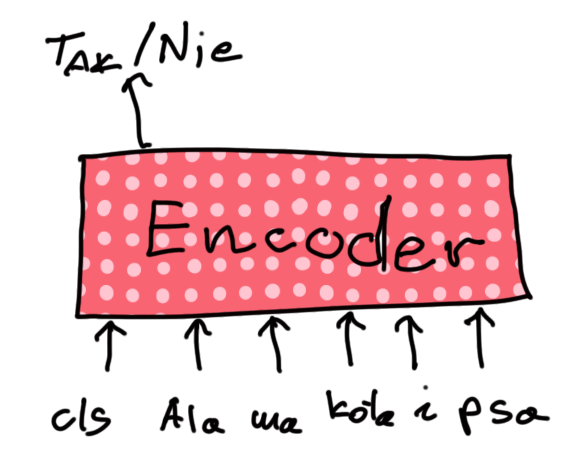

- fine-tuning
  - pre-token jest wciąż używany
  - zwykle dodawane są nowe warstwy z losową inicjalizacją
  - uzyskany token dla znacznika jest reprezentacją sekwencji dla uczenia przez wartwę FF
  - BERT zawiera dodatkowy koszt dla predykcji czy kolejna sekwencja (zdanie) nastepuje po pierwszej
  - szereg modeli inspirowanych przez BERT: RoBERTa, ALBERT, ELECTRA, SpanBERT, etc.

## Modele wykorzystujące enkoder jak i dekoder

- enkoder generuje tą samą liczbę tokenów co wejściowa - nie nadaje się wprost do tłumaczenia
  - konieczne są enkoder - dekoder każdy zależny od wygenerowanego dotąd własnego ciągu tokenów
  - dekoder musi wykorzystywać atencję krzyżową cross-attention zależną także od tokenów enkodera
  - atencja dekodera musi być zależna jedynie od poprzednich tokenów
  - modele BART oraz Text to text transfer transformer T5

### Text to text transfer transformer T5

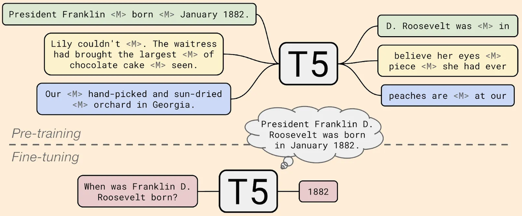

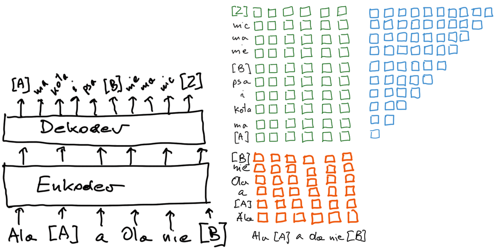

- enkoder: wejściem jest opis zadania ("wygeneruj rysunek", "oceń sentyment") z dodanymi tokenami wejściowymi (zdanie)
  - sekwencje z tokenami losowo zasłoniętymi specjalnymi wartościami: dla zdania **Ala ma kota i psa a Ola nie ma nic** enkoder dostaje **Ala [A] a Ola nie [B]**
  - kolejne zasłonięte tokeny są łączone w jeden
  - zdanie jest zakończone dodatkowym specjalnym tokenem
  - dla sekwencji atencji tokeny są zależne tylko od poprzednich
  - w self-atencji enkoder - dekoder wszystkie zależności są używane (w przeszłość i w przód)
- dekoder: generowanie odpowiedniego dla zadania wyjścia
  - wartością target jest **[A] ma kota i psa [B] nie ma nic [Z]** gdzie [Z] jest znacznikiem końca
- enkoder i dekoder są uczone w pre-trainingu na olbrzymiej bazie wyczyszczonych zdań (ponad 1000 miliardów słów) opartych na przeglądaniu sieci C4 (colossal clean crawled corpus)
- fine-tuning dla konkretnych zadań i konkretnych problemów
  - ta sama architektura, ale T5 zawiera dodatkowo opis zadania
  - enkoder generuje dopełnienie przetworzone zdanie
  - dekoder tworzy wyjście o dowolnej długości będące realizacją zadania
    - typowym zadaniem jest wykonanie skrótu tekstu
- w modelu Imagen dekoder jest w stanie generować obrazy według podanego opisu na wejściu do enkodera

## Generative pre-training GPT — tylko dekoder

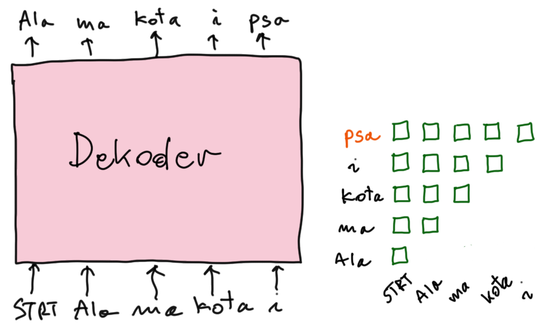

- GPT i inne są modelami auto — regresywnego uczenia
  - modelem jest sam dekoder
  - dekoder generuje kolejny token
  - atencja jest tylko **do tyłu**, tym bardziej, że tokeny **wprzód** nie są jeszcze znane
  - GPT nauczony dla ok. 100 milionów parametrów z koniecznością douczania dla konkretnych zadań
  - GPT-2 miał już ponad 1.5 miliarda parametrów uczonych na ponad 40 GB tekstu
  - kolejne modele o rzędy wielkości więcej
    - 96 warstw
    - na zmianę bloki atencji i MLP

```python
import platform

has_gpu = torch.cuda.is_available()
has_mps = getattr(torch,'has_mps',False)

device = "mps" if getattr(torch,'has_mps',False) \
    else "gpu" if torch.cuda.is_available() else "cpu"

print(f"Python Platform: {platform.platform()}")  # Python Platform: macOS-13.3.1-arm64-arm-64bit
print(f"PyTorch Version: {torch.__version__}")  # PyTsorch Version: 2.0.1

print("GPU is", "available" if has_gpu else "NOT AVAILABLE")  # GPU is NOT AVAILABLE
print("MPS is", "AVAILABLE" if has_mps else "NOT AVAILABLE")  # MPS is AVAILABLE

print(f"Target device is {device}") #Target device is mps
```

```
Python Platform: macOS-13.5.2-arm64-arm-64bit
PyTorch Version: 2.0.1
GPU is NOT AVAILABLE
MPS is AVAILABLE
Target device is mps
```

## Ale jak Transformery działają?

- niezwykle złożone
- koncepcja mechanicznego reverse engineering (Anthropic)
  - zero-warstwowe transformery są w stanie modelować bigramy
  - jedno-warstwowe, tylko z atencją są złożeniem bigramów oraz trigramów z opuszczonymi elementami
  - Dwuwarstwowe tworzą złożone struktury (obwody)
  - złożenia głów atencji

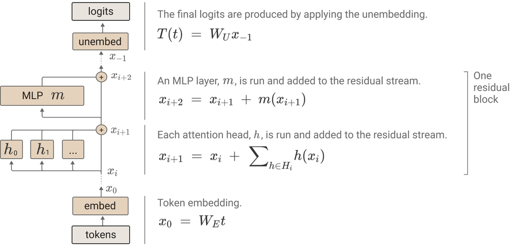

source: Anthropic

- macierz embeddingu jest uczona
  - tokeny maj więc jakiś związek z wejściowymi wartościami
- model składa się z szeregu połączeń rezydualnych: głowic atencji oraz MLP
- za końcowym "od-embedowaniem" następuje policzenie logitów
- efektywnie cały czas działa połączenie rezydualne
  - nie ma w nim żadnego przetwarzania
  - przemieszanie połączenia rezydualnego nie wpływa na przetwarzanie

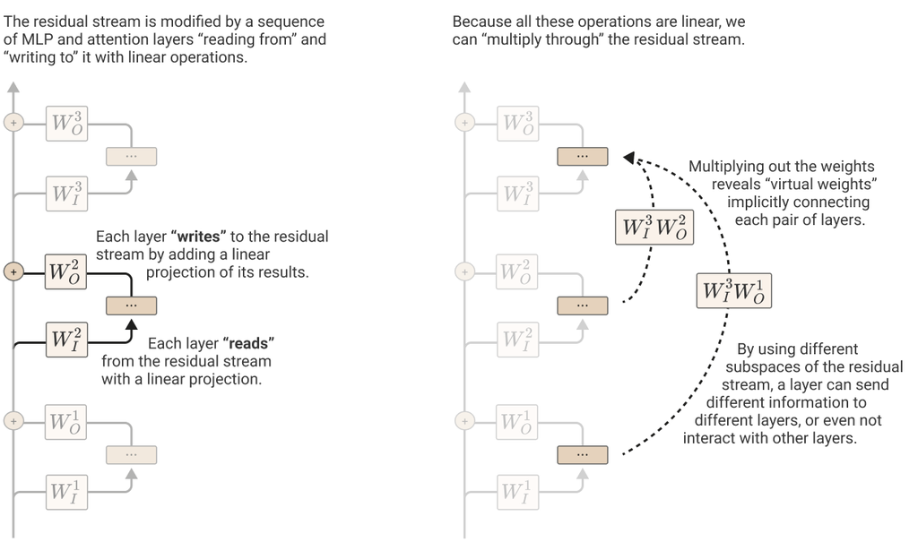

source: Anthropic